# Chapter 8 Assignment: Bagging, RF, BART

Joe Dickerson

2025-10-26

```r
library(ISLR2)
library(randomForest)
library(BART)
data(Carseats)
set.seed(1)
```

Apply boosting, bagging, random forests, and BART to a data set of your choice. Be sure to fit the models on a training set and to evaluate their performance on a test set. How accurate are the results compared to simple methods like linear or logistic regression? Which of these approaches yields the best performance?

## Bagging

When we use bagging, we get an MSE of 2.624.

```r
train <- sample(1:nrow(Carseats), (nrow(Carseats)/2))
test <- Carseats[-train, ]

bag.Carseats <- randomForest(Sales ~ ., data = Carseats, subset = train,
                         mtry = (ncol(Carseats) - 1), importance = TRUE)

bag.Carseats
```

```
##
## Call:
##  randomForest(formula = Sales ~ ., data = Carseats, mtry = (ncol(Carseats) -      1), importance = TRUE, subset = train)
##                Type of random forest: regression
##                      Number of trees: 500
## No. of variables tried at each split: 10
##
##           Mean of squared residuals: 2.87164
##                     % Var explained: 63.48
```

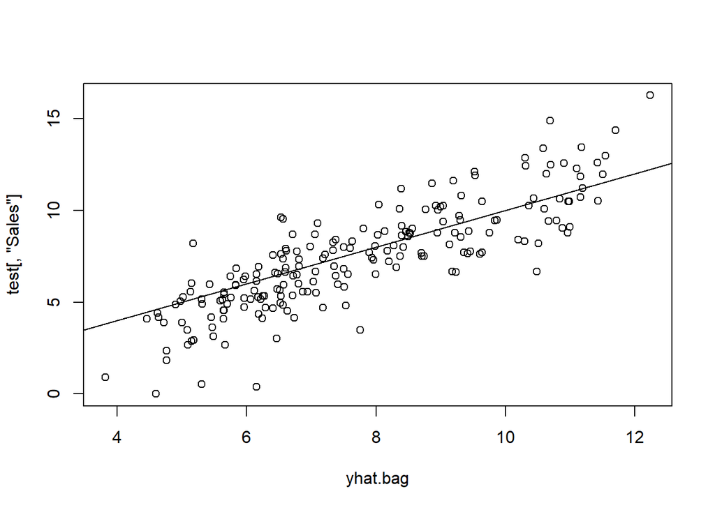

```r
Carseats.test <- Carseats[-train, "Sales"]

yhat.bag <- predict(bag.Carseats, newdata = test)
plot(yhat.bag, test[,"Sales"])
abline(0, 1)
```

```r
mean((yhat.bag - test[,"Sales"])^2) ## test set MSE: 2.624
```

```
## [1] 2.623527
```

## Random Forest

When we using random forests, we get an MSE of 3.001.

```r
rf.Carseats <- randomForest(Sales ~ ., data = Carseats, subset = train,
                            mtry = round(sqrt(ncol(Carseats))),
                            importance = TRUE)
yhat.rf <- predict(rf.Carseats, newdata = test)

mean((yhat.rf - test[,"Sales"])^2) ## test set MSE: 3.001
```

```
## [1] 3.001375
```

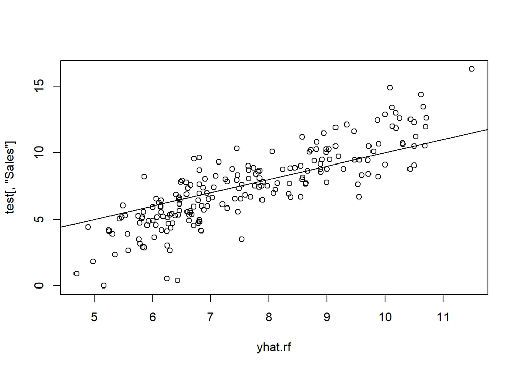

```r
plot(yhat.rf, test[,"Sales"])
abline(0, 1)
```

## BART

When we use BART, we get an MSE of 1.438. Of the three methods, this is the most effective so far.

```r
x <- Carseats[, 2:11]
y <- Carseats[, "Sales"]
xtrain <- x[train, ]
ytrain <- y[train]

xtest <- x[-train, ]
ytest <- y[-train]

bartfit <- gbart(xtrain, ytrain, x.test = xtest)
```

```
## *****Calling gbart: type=1
## *****Data:
## data:n,p,np: 200, 14, 200
## y1,yn: 2.781850, 1.091850
## x1,x[n*p]: 107.000000, 1.000000
## xp1,xp[np*p]: 111.000000, 1.000000
## *****Number of Trees: 200
## *****Number of Cut Points: 63 ... 1
## *****burn,nd,thin: 100,1000,1
## *****Prior:beta,alpha,tau,nu,lambda,offset: 2,0.95,0.273474,3,0.23074,7.57815
## *****sigma: 1.088371
## *****w (weights): 1.000000 ... 1.000000
## *****Dirichlet:sparse,theta,omega,a,b,rho,augment: 0,0,1,0.5,1,14,0
## *****printevery: 100
##
## MCMC
## done 0 (out of 1100)
## done 100 (out of 1100)
## done 200 (out of 1100)
## done 300 (out of 1100)
## done 400 (out of 1100)
## done 500 (out of 1100)
## done 600 (out of 1100)
## done 700 (out of 1100)
## done 800 (out of 1100)
## done 900 (out of 1100)
## done 1000 (out of 1100)
## time: 2s
## trcnt,tecnt: 1000,1000
```

```r
yhat.bart <- bartfit$yhat.test.mean

mean((ytest - yhat.bart)^2) ## test set MSE: 1.438
```

```
## [1] 1.438366
```

```r
ord <- order(bartfit$varcount.mean, decreasing = T)
bartfit$varcount.mean[ord]
```

```
##       Price   CompPrice   Education  ShelveLoc2         US2  ShelveLoc1
##      23.965      18.554      18.060      17.808      17.405      17.175
##      Urban2  ShelveLoc3  Population      Income      Urban1         Age
##      16.489      16.462      16.015      15.751      15.669      15.482
## Advertising         US1
##      15.415      14.790
```

```r
## checking how many times each variable appeared in the collection of trees
```

## Linear Model

Strangely, a simple linear model seems to fit this data the best of the methods, just judging by the MSE alone, which for the linear model is 1.007, the lowest of all the methods.

```r
lmod <- lm(Sales ~ ., data = Carseats)
summary(lmod)
```

```
##
## Call:
## lm(formula = Sales ~ ., data = Carseats)
##
## Residuals:
##     Min      1Q  Median      3Q     Max
## -2.8692 -0.6908  0.0211  0.6636  3.4115
##
## Coefficients:
##                   Estimate Std. Error t value Pr(>|t|)
## (Intercept)      5.6606231  0.6034487   9.380  < 2e-16 ***
## CompPrice        0.0928153  0.0041477  22.378  < 2e-16 ***
## Income           0.0158028  0.0018451   8.565 2.58e-16 ***
## Advertising      0.1230951  0.0111237  11.066  < 2e-16 ***
## Population       0.0002079  0.0003705   0.561    0.575
## Price           -0.0953579  0.0026711 -35.700  < 2e-16 ***
## ShelveLocGood    4.8501827  0.1531100  31.678  < 2e-16 ***
## ShelveLocMedium  1.9567148  0.1261056  15.516  < 2e-16 ***
## Age             -0.0460452  0.0031817 -14.472  < 2e-16 ***
## Education       -0.0211018  0.0197205  -1.070    0.285
## UrbanYes         0.1228864  0.1129761   1.088    0.277
## USYes           -0.1840928  0.1498423  -1.229    0.220
## ---
## Signif. codes:  0 '***' 0.001 '**' 0.01 '*' 0.05 '.' 0.1 ' ' 1
##
## Residual standard error: 1.019 on 388 degrees of freedom
## Multiple R-squared:  0.8734, Adjusted R-squared:  0.8698
## F-statistic: 243.4 on 11 and 388 DF,  p-value: < 2.2e-16
```

```r
lm.preds <- predict(lmod)

mean((Carseats$Sales - lm.preds)^2) ## MSE: 1.007
```

```
## [1] 1.007084
```

## Conclusion

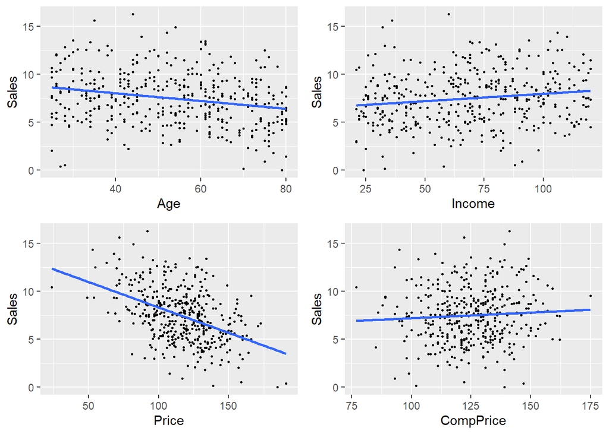

```r
library(tidyverse)
library(gridExtra)

p1 <- Carseats %>%
  ggplot(aes(x = Age, y = Sales)) +
  geom_point(size = .5) +
  geom_smooth(fill = NA, method = lm)

p2 <- Carseats %>%
  ggplot(aes(x = Income, y = Sales)) +
  geom_point(size = .5) +
  geom_smooth(fill = NA, method = lm)

p3 <- Carseats %>%
  ggplot(aes(x = Price, y = Sales)) +
  geom_point(size = .5) +
  geom_smooth(fill = NA, method = lm)

p4 <- Carseats %>%
  ggplot(aes(x = CompPrice, y = Sales)) +
  geom_point(size = .5) +
  geom_smooth(fill = NA, method = lm)

grid.arrange(p1, p2, p3, p4, ncol = 2)
```